# Percent of Total Earnings Visual

Gonzalo Aguilar

2022-07-23

### Setting up enviornment

```r
library(tidyverse)
```

```r
library(ggplot2)
```

### Importing data from files

```r
top10_DF <- read_csv("top10_DF.csv")
```

### Making sure my data landed safely

```r
glimpse(top10_DF)
```

```
## Rows: 10
## Columns: 7
## $ ...1             <dbl> 1, 2, 3, 4, 5, 6, 7, 8, 9, 10
## $ player_id        <chr> "C6", "Arcitys", "Clayster", "aBeZy", "Simp", "Scump"…
## $ player_name      <chr> "Ian Porter", "Alec Sanderson", "James Eubanks", "Tyl…
## $ total_earnings   <chr> "$1,360,592.80", "$1,207,179.09", "$1,198,021.68", "$…
## $ highest_payout   <chr> "Call of Duty: Modern Warfare", "Call of Duty: Black …
## $ game_total       <chr> "$353,000.00", "$487,500.00", "$365,500.00", "$483,75…
## $ percent_of_total <chr> "25.94%", "40.38%", "30.51%", "41.09%", "44.01%", "22…
```

### Starting visual

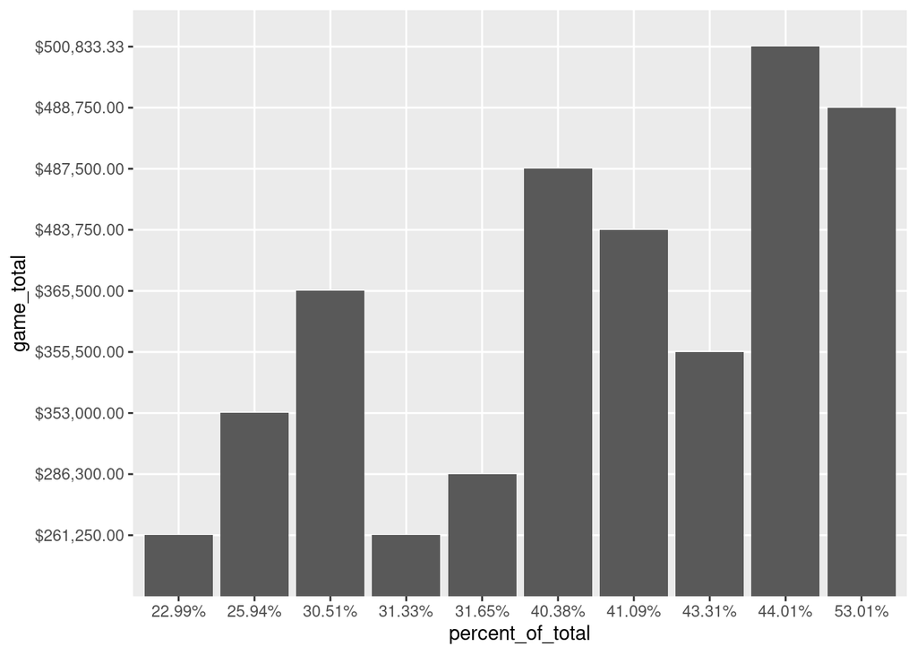

```r
ggplot(data=top10_DF,mapping=aes(x=percent_of_total,y=game_total))+geom_col()
```

## Visual Overview

The visual is no where what I wanted to represent, but it was start!

So I used my current knowledge of R and my Googling skills to carefully add details to get to the desired end result

- Represent each player_id and their total earnings
- Fill in the game that contributed to their highest payout by color per player 📊
- Add the tittle, caption and source the data
- Scale the X-axis to remove clutter from the numbers representing the percent of total earnings

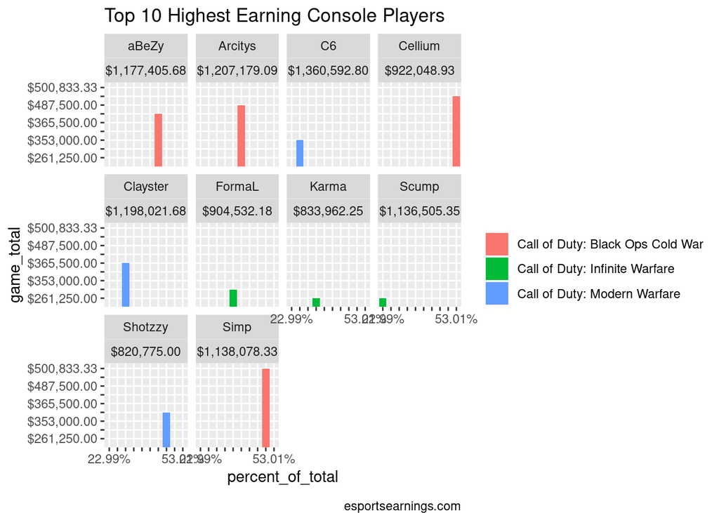

```r
ggplot(data= top10_DF,mapping=aes(x=percent_of_total,y=game_total,fill=highest_payout))+geom_col()+facet_wrap(player_id~total_earnings)+scale_x_discrete(guide = guide_axis(check.overlap = TRUE))+theme(legend.title = element_blank())+labs(title = "Top 10 Highest Earning Console Players",caption = "esportsearnings.com")+scale_y_discrete(guide = guide_axis(check.overlap = TRUE))+theme(plot.caption= element_text(vjust = -2))
```

### Final thoughts

The visual represents all top 10 console player stats focusing on the percent of total earnings calculated by the players highest payout game filled with color. what games are paying that much to pro players? The popular **FPS Call of Duty franchise**

- Call of Duty Black ops Cold War November 13, 2020 🟥
- Call of duty Modern warfare releasing in October 25, 2019 🟦
- Call of Duty Call of Duty Infinite Warfare November 4, 2016 🟩

My favorite Call of Duty game currently is Call of Duty Black ops 4.